# Methods to find Linear Reg Coeff

Shyam BV

March 15, 2018

## Introduction

Regression is one of the most powerful algorithm to model the data. It is one of the most interpretable method compared to other algorithms. It can take different forms depending on the type of dataset.

## Dataset

Dataset which we are going to use in Big mart sales dataset[https://datahack.analyticsvidhya.com/contest/practice-problem-big-mart-sales-iii/]. It has different columns, below is the snapshot of the dataset.

For simplicity, we will drop the `NA's` and sample `1000` rows.

```r
df_original = read.csv('./data/Train_UWu5bXk.csv',skipNul = TRUE,na.strings = c(' ','','NA',NA))

df_original = na.omit(df_original)

df = df_original[sample(nrow(df_original),1000),]

head(df)
```

```
##      Item_Identifier Item_Weight Item_Fat_Content Item_Visibility
## 8496           FDE22       9.695          Low Fat      0.02956722
## 5751           FDV26      20.250          Regular      0.07647070
## 6271           FDW14       8.300          Regular      0.03836719
## 5505           FDQ26      13.500          Regular      0.00000000
## 3700           FDJ45      17.750               LF      0.07370969
## 5931           NCA18      10.100          Low Fat      0.05603091
##        Item_Type Item_MRP Outlet_Identifier Outlet_Establishment_Year
## 8496 Snack Foods 160.4920            OUT035                      2004
## 5751       Dairy 196.1794            OUT018                      2009
## 6271       Dairy  87.1198            OUT018                      2009
## 5505       Dairy  57.8562            OUT049                      1999
## 3700     Seafood  35.1216            OUT018                      2009
## 5931   Household 115.1492            OUT013                      1987
##      Outlet_Size Outlet_Location_Type       Outlet_Type Item_Outlet_Sales
## 8496       Small               Tier 2 Supermarket Type1         4314.3840
## 5751      Medium               Tier 3 Supermarket Type2         2731.1116
## 6271      Medium               Tier 3 Supermarket Type2          959.4178
## 5505      Medium               Tier 1 Supermarket Type1          711.0744
## 3700      Medium               Tier 3 Supermarket Type2          415.4592
## 5931        High               Tier 3 Supermarket Type1         1737.7380
```

There are a total of 11 predictors and one dependent variables `sales` which need to predict. It also contains categorical variables. For the sake of simplicity, we will omit categorical variables and use one quantative variable with dependent variable.

## Simple models

Lets start with a simple model using quantitative predictors(Item_MRP)

### Model1 - Null Model

Below is the null model, if we do not predict any thing and not use any model. This is just an average of the sales.

Defining function for MSE:

```r
mse = function(y,y_hat){

y = c(y)
y_hat=c(y_hat)

return(mean((y-y_hat)^2))
}
```

```r
mse(df$Item_Outlet_Sales,mean(df$Item_Outlet_Sales))
```

```
## [1] 2235150
```

That is too much of error if we just use null model and an average of it.

## Model2 - Simple Linear Regression function

Lets try a simple linear regression which `Item_MRP` as a predictor variable of `Item_Outlet_Sales`

```r
simple_model = lm(Item_Outlet_Sales ~  Item_MRP,df)

summary(simple_model)
```

```
##
## Call:
## lm(formula = Item_Outlet_Sales ~ Item_MRP, data = df)
##
## Residuals:
##     Min      1Q  Median      3Q     Max
## -3776.8  -621.4   -55.5   550.4  5484.8
##
## Coefficients:
##             Estimate Std. Error t value Pr(>|t|)
## (Intercept) -92.4567    85.9302  -1.076    0.282
## Item_MRP     16.7133     0.5616  29.758   <2e-16 ***
## ---
## Signif. codes:  0 '***' 0.001 '**' 0.01 '*' 0.05 '.' 0.1 ' ' 1
##
## Residual standard error: 1089 on 998 degrees of freedom
## Multiple R-squared:  0.4701, Adjusted R-squared:  0.4696
## F-statistic: 885.5 on 1 and 998 DF,  p-value: < 2.2e-16
```

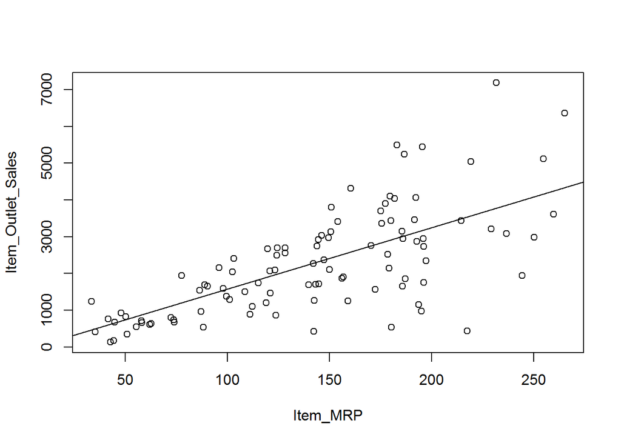

```r
#plot(simple_model$coefficients*df$Item_MRP,df$Item_Outlet_Sales)

# For simplicity, plot only 100 points
plot(Item_Outlet_Sales ~ Item_MRP, df[seq(100),])

abline(simple_model)
```

```r
summary(simple_model)
```

```
##
## Call:
## lm(formula = Item_Outlet_Sales ~ Item_MRP, data = df)
##
## Residuals:
##     Min      1Q  Median      3Q     Max
## -3776.8  -621.4   -55.5   550.4  5484.8
##
## Coefficients:
##             Estimate Std. Error t value Pr(>|t|)
## (Intercept) -92.4567    85.9302  -1.076    0.282
## Item_MRP     16.7133     0.5616  29.758   <2e-16 ***
## ---
## Signif. codes:  0 '***' 0.001 '**' 0.01 '*' 0.05 '.' 0.1 ' ' 1
##
## Residual standard error: 1089 on 998 degrees of freedom
## Multiple R-squared:  0.4701, Adjusted R-squared:  0.4696
## F-statistic: 885.5 on 1 and 998 DF,  p-value: < 2.2e-16
```

This is going to be our model using R build-in functions. Now we will use other methods to calculate the coefficients(beta_hat)

## Model3 - Manual Slope and Intercept

Coefficents can be calculated using different summary statistics.

```r
x = as.matrix(df$Item_MRP)
y = as.matrix(df$Item_Outlet_Sales)

slope <- cor(x, y) * (sd(y) / sd(x))
intercept <- mean(y) - (slope * mean(x))

print(paste0("Slope: ",round(slope,2)))
```

```
## [1] "Slope: 16.71"
```

```r
print(paste0("Intercept: ",round(intercept,2)))
```

```
## [1] "Intercept: -92.46"
```

This method is easy when we have one or two predictor variables. But gets hard if there are many predictors.

## Model 4 - Ordinary Least Squares(OLS)

This is one of the famous method for calculating the parameters of linear regression. Mathematically, it is reducing the errors.

```r
x = as.matrix(cbind (1, df$Item_MRP))
y = as.matrix(df$Item_Outlet_Sales)



## Choose beta-hat to minimize the sum of squared residuals
## resulting in matrix of estimated coefficients:
bh = round(solve(t(x)%*%x)%*%t(x)%*%y, digits=2)

## Label and organize results into a data frame
beta.hat = as.data.frame(cbind(c("Intercept","Beta"),bh))
names(beta.hat) = c("Coeff.","Est")
beta.hat
```

```
##      Coeff.    Est
## 1 Intercept -92.46
## 2      Beta  16.71
```

This is most commonly used method when we have less number of predictors. When having multiple predictors with a high number of data points, this method is too expensive. That is when we look for cost optimazation using gradient decent algorithm.

## Model5 - Gradient Decent using Optim

This is one of the most used method in many machine learning problems. It is robust to multiple predictors and many observations. It simply uses graident algorithm to find the coefficients. Below is the mathematical form of gradient decent.

Vector form of gradient decent

$\frac{1}{2m}\sum((X.\theta - Y)^2)$

Here we create a function to reduce the least squares using `optim` function. Beta is initially assigned as 0.

```r
fnRSS = function(vBeta, vY, mX) {
  return(sum((vY - mX %*% vBeta)^2))
}

mX = as.matrix(df$Item_MRP)
mX <- cbind(1, matrix(mX))
vY = as.matrix(df$Item_Outlet_Sales)

vBeta0 = rep(0, ncol(mX))

optimLinReg = optim(vBeta0, fnRSS,
                    mX = mX, vY = vY, method = 'BFGS',
                    hessian=TRUE)

print(optimLinReg$par)
```

```
## [1] -92.45668  16.71332
```

So we have tried different methods to find out the coefficents of a linear regression models.